# R script to define species that are potential key contributor to a given ecosystem service.

gueguen

Thu Sep 20 10:01:29 2018

Step 1: The goal is to model a given ecosystem service (Y) according to Environmental (E) and  
Socio-Economic conditions (SE) and species richness (R); to check its relevance according to its  
explanatory power and to save its Akaike Information Criterion (AIC_M0) as a reference for the next step

Step2: The goal is to identify species key for the studied ecosystem service (Y) adding each candidate  
species (presence-absence) as an additional explanatory variable to M0 to compute model M1 and its  
associated AIC (AIC_M1). Finally, a species is declared as a key potential contributor to the ecosystem  
service if ΔAIC (AIC_M0-AIC_M1) > 4 and if its partial effect is positive (positive coefficient in the model)

Here we apply this framework to define the “key plant species” for total plant biomass  
Code by Eva Maire (eva.maire@umontpellier.fr). Last update on 2018-06-26  
This code provides results of analysis used in Maire, E., Villéger, S., Graham, N., Hoey, A., Cinner, J.,  
Ferse, S., Aliaume, C, Booth, D., Feary, D., Kulbicki, M., Sandin, S., Vigliola, L. & Mouillot, D. (2018).  
Community-wide scan identifies plant species associated to coral reef services globally. Proceedings B.

```r
rm(list=ls())

## make this document cache friendly
knitr::opts_chunk$set(cache=TRUE)

## loading required libraries
require(corrplot)
require(MuMIn)
require(lme4)
require(gam)
require(optimx)
library(foreach)
library(foreign)
library(ade4)
library(ggplot2)
library(ggthemes)
library(reshape2)

# setting working directory
my_path <- "/home/gueguen/Documents/_SCRIPTS/2018_09_NPP_Functio/2_Alps_version/" #  <= "Biomass" folder
setwd(my_path)
```

# LOADING AND PREPARING DATA

```r
load("Data_for_Wilfried.RData")
dim(commplots) ## sites x species
```

```
## [1] 11172  1210
```

```r
dim(env.data) ## sites x env
```

```
## [1] 11172    58
```

```r
dim(ss.trts) ## species x traits
```

```
## [1] 1210    8
```

```r
## Add slope values and Chamois classification
suppData = read.dbf("PlotsAlps_slope_classifChamois.dbf")
env.data = unique(merge(env.data, suppData[, c("longL93fic","latL93fich","slope")], by = c("longL93fic","latL93fich")))
env.data = unique(merge(env.data, suppData[, c("longL93fic","latL93fich","chamois")], by = c("longL93fic","latL93fich")))

## Check correspondance between habitat classifications
# table(env.data$Forests, env.data$lnus)
# table(env.data$Forest_trts, env.data$lnus)
# table(env.data$Forest_both, env.data$lnus)
#
# table(env.data$lnus, env.data$chamois)
```

## (i) Loading complete dataset of environnemental drivers, productivity, etc

```r
nrow(env.data) ## 11172 plots are available
```

```
## [1] 11172
```

```r
rownames(env.data) = env.data$numchrono

## Compute annual mean precipitation
env.data$prec_mean = rowMeans(env.data[, c(paste0("prec_0", 1:9), "prec_10", "prec_11", "prec_12")])

## Keep only variables of interest
env.data = env.data[, c("Mountain_belts" ,
                        "lnus",
                        "Elevation",
                        "slope",
                        "temp_mean",
                        "prec_mean",
                        "aridity",
                        "evi_mn",
                        "X_savi_mn",
                        "msavi_mn",
                        "ndmi_mn",
                        "ndvi_mn",
                        "NPP_Mean")]

## Remove NAs
env.data = na.exclude(env.data) ## 10948

## All the quantitative covariables are standardised.
for (i in 1:2) env.data[, i] = as.factor(env.data[, i])
for (i in 3:ncol(env.data)) env.data[, i] = as.vector(scale(env.data[, i]))
summary(env.data)
```

```
##  Mountain_belts      lnus        Elevation            slope
##  1:   1         34     :4704   Min.   :-1.73549   Min.   :-1.3627
##  2:  31         32     :1789   1st Qu.:-0.88215   1st Qu.:-0.8501
##  3: 817         31     :1603   Median :-0.05862   Median :-0.1318
##  4:2961         45     :1046   Mean   : 0.00000   Mean   : 0.0000
##  5:7137         211    : 736   3rd Qu.: 0.94462   3rd Qu.: 0.6903
##  6:   1         36     : 555   Max.   : 2.32917   Max.   : 4.7772
##                 (Other): 515
##    temp_mean          prec_mean          aridity            evi_mn
##  Min.   :-2.26883   Min.   :-2.0575   Min.   :-1.7092   Min.   :-3.3816
##  1st Qu.:-0.86541   1st Qu.:-0.7176   1st Qu.:-0.7917   1st Qu.:-0.7058
##  Median : 0.07132   Median :-0.1366   Median :-0.1056   Median : 0.1778
##  Mean   : 0.00000   Mean   : 0.0000   Mean   : 0.0000   Mean   : 0.0000
##  3rd Qu.: 0.88235   3rd Qu.: 0.5941   3rd Qu.: 0.6670   3rd Qu.: 0.8045
##  Max.   : 1.89238   Max.   : 3.7271   Max.   : 3.4830   Max.   : 2.1316
##
##    X_savi_mn          msavi_mn          ndmi_mn            ndvi_mn
##  Min.   :-2.7565   Min.   :-2.6521   Min.   :-2.32647   Min.   :-3.1050
##  1st Qu.:-0.7494   1st Qu.:-0.7516   1st Qu.:-0.90714   1st Qu.:-0.7505
##  Median : 0.1342   Median : 0.1229   Median :-0.07394   Median : 0.1095
##  Mean   : 0.0000   Mean   : 0.0000   Mean   : 0.00000   Mean   : 0.0000
##  3rd Qu.: 0.7986   3rd Qu.: 0.7940   3rd Qu.: 0.90960   3rd Qu.: 0.7601
##  Max.   : 2.5115   Max.   : 2.6149   Max.   : 2.08610   Max.   : 3.0677
##
##     NPP_Mean
##  Min.   :-2.6842
##  1st Qu.:-0.7225
##  Median : 0.3287
##  Mean   : 0.0000
##  3rd Qu.: 0.8060
##  Max.   : 2.1862
##
```

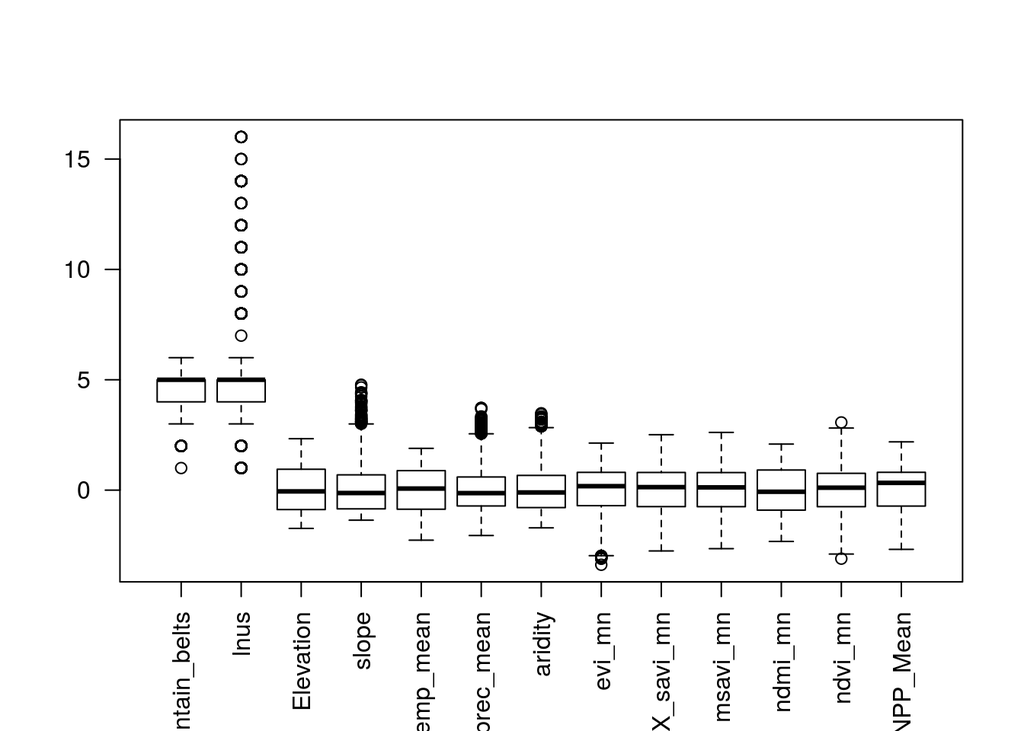

```r
boxplot(env.data, las = 2)
```

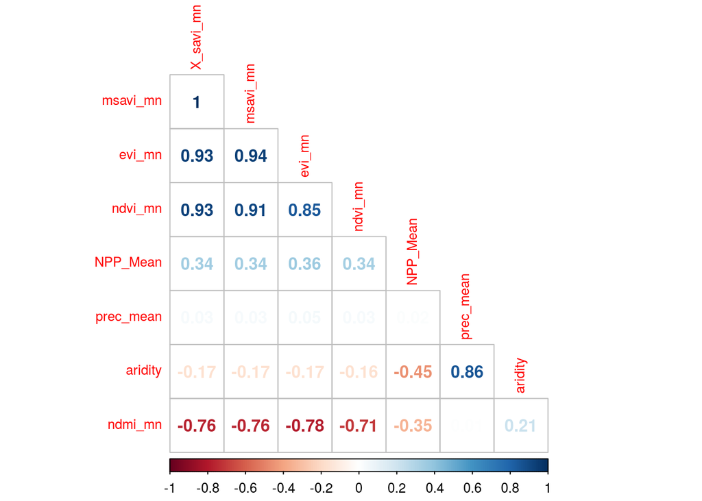

```r
## Check for correlation between variables
corrplot(cor(env.data[, 6:ncol(env.data)]), method = "number"
         , type = "lower", diag = F, tl.cex = 0.8
         , order = "FPC")
```

```r
## Remove Elevation
## !!! aridity correlated with prec_mean
## !!! temp_mean correlated with NPP_Mean
```

## (ii) Loading the matrix which describes presence/absence of species for each site

```r
## Transform into 0/1
presence_plant_species = commplots
presence_plant_species[which(presence_plant_species > 0)] = 1

## We excluded species present on less than 1% of the sites
limit <- round(0.01 * nrow(env.data), 0) ## 109
plant_sp <- colnames(presence_plant_species)

occurrence <- apply(presence_plant_species, 2, sum)
length(which(occurrence >= limit)) # we retained 444 plant species as candidates
```

```
## [1] 444
```

```r
required_threshold <- which(occurrence >= limit)

## Keeping only candidates species and their presence/absence
candidates_species <- plant_sp[required_threshold]
presence_candidates <- presence_plant_species[,required_threshold]
dim(presence_candidates)
```

```
## [1] 11172   444
```

```r
## Verifying that the 2 datasets have the same rows
env_data = env.data[which(rownames(env.data) %in% rownames(presence_candidates)), ]
presence_candidates = presence_candidates[which(rownames(presence_candidates) %in% rownames(env.data)), ]
length(is.element(rownames(env_data),rownames(presence_candidates))) # 10948 OK
```

```
## [1] 10948
```

```r
## Reorder lines and compute Species Richness
env_data = env_data[order(rownames(env_data)), ]
presence_candidates = presence_candidates[rownames(env_data), ]
env_data$SR = rowSums(presence_candidates, na.rm = T)


# dim(presence_candidates) ## sites x species
# dim(env_data) ## sites x env
# dim(ss.trts) ## species x traits
```

## (iii) Loading functional traits of species

```r
Functional_traits = ss.trts
summary(Functional_traits)
```

```
##       LDMC             SLA             PL_VEG_H        PL_REPR_H
##  Min.   : 38.24   Min.   :  2.239   Min.   :   0.5   Min.   :   1.95
##  1st Qu.:159.37   1st Qu.: 15.755   1st Qu.:  14.0   1st Qu.:  20.00
##  Median :206.74   Median : 21.750   Median :  29.0   Median :  37.50
##  Mean   :216.57   Mean   : 23.315   Mean   : 128.0   Mean   :  97.70
##  3rd Qu.:264.20   3rd Qu.: 28.700   3rd Qu.:  53.0   3rd Qu.:  64.75
##  Max.   :638.33   Max.   :144.775   Max.   :5000.0   Max.   :3500.00
##  NA's   :80                                          NA's   :163
##      SEEDM            DISP_VITTOZ            WOODY            GROWTHF
##  Min.   :    0.001   6      :253   Frutescent   : 132   forbs     :  54
##  1st Qu.:    0.214   7      :225   Herbaceous   :1002   graminoids:  17
##  Median :    0.845   2      :209   Suffrutescent:  60   legumes   :   7
##  Mean   :   40.428   3      :148   NA's         :  16   NA's      :1132
##  3rd Qu.:    3.181   5      :135
##  Max.   :11305.975   (Other):203
##                      NA's   : 37
```

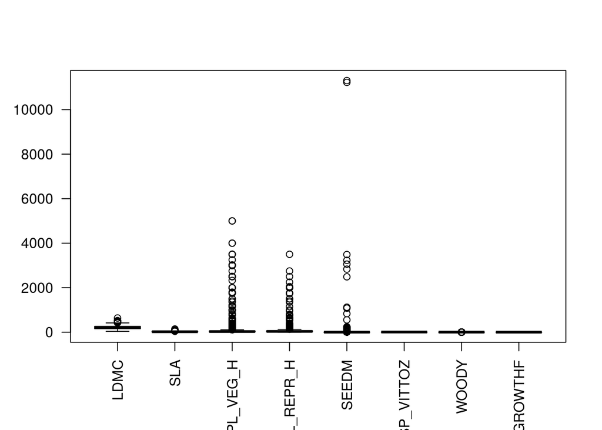

```r
boxplot(Functional_traits, las = 2)
```

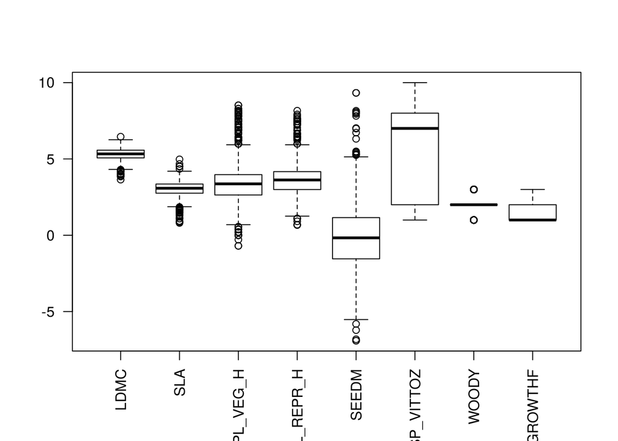

```r
Functional_traits$SEEDM = log(Functional_traits$SEEDM)
Functional_traits$PL_VEG_H = log(Functional_traits$PL_VEG_H)
Functional_traits$PL_REPR_H = log(Functional_traits$PL_REPR_H)
Functional_traits$LDMC = log(Functional_traits$LDMC)
Functional_traits$SLA = log(Functional_traits$SLA)
boxplot(Functional_traits, las = 2)
```

```r
dim(Functional_traits)
```

```
## [1] 1210    8
```

```r
dim(na.exclude(Functional_traits))
```

```
## [1] 53  8
```

```r
## rm GROWTHF
dim(na.exclude(Functional_traits[, c("LDMC","SLA","PL_VEG_H","PL_REPR_H","SEEDM","DISP_VITTOZ","WOODY")]))
```

```
## [1] 964   7
```

# DEFINING M0 MODEL : combining all variables

```r
# par(mfrow=c(2,3))
# plot(temp_mean ~ lnus, env_data)
# plot(prec_mean ~ lnus, env_data)
# plot(slope ~ lnus, env_data)
# plot(temp_mean ~ Mountain_belts, env_data)
# plot(prec_mean ~ Mountain_belts, env_data)
# plot(slope ~ Mountain_belts, env_data)

vari_prod = c("ndvi_mn", "X_savi_mn", "msavi_mn", "evi_mn", "ndmi_mn", "NPP_Mean")
vari_hab = c("Mountain_belts", "lnus")
vari_env = c("temp_mean", "prec_mean", "aridity")
vari_topo = "slope"
vari_SP = c("SR")
vari_all = c(vari_hab, vari_env, vari_topo, vari_SP)

comb_vari = unlist(sapply(1:length(vari_all), function(x)
  apply(combn(vari_all, x), 2, function(y)
    paste0(y, collapse = "."))))
## remove combination with correlated variables
comb_vari = comb_vari[-grep("prec_mean.aridity", comb_vari)]
comb_vari = comb_vari[-grep("temp_mean.aridity", comb_vari)]

comb_mod = expand.grid(prod = vari_prod, expl = comb_vari, stringsAsFactors = F)
## remove combination of NPP_Mean with temp_mean
comb_mod = comb_mod[-intersect(which(comb_mod$prod == "NPP_Mean")
                               , grep("temp_mean", comb_mod$expl)),]
```

```r
## STEP 1: Computing initial plant biomass model (M0)
COMPAR = foreach(vp = comb_mod$prod, ve = comb_mod$expl, .combine = "rbind") %do%
{
  # cat("\n Calculate model M0 for ", vp, " with variables ", ve, "...\n")

  M0 = as.formula(paste0(vp, " ~ ", gsub("[.]", " + ", ve)))
  mod = "glm"
  type_mod = strsplit(mod, "_")[[1]][1]
  supp_arg = ifelse(type_mod == "lmer"
                    , paste0(", control = lmerControl(optimizer = 'optimx', calc.derivs = FALSE,"
                             , "optCtrl = list(method = 'nlminb', starttests = FALSE, kkt = FALSE))")
                    , "")
  eval(parse(text = paste0("M0 = ", type_mod, "(M0, data = env_data", supp_arg, ")")))

  res = data.frame(PROD = vp, VAR = ve, TYPE_MOD = mod, AIC = AIC(M0), R2 = r.squaredGLMM(M0)[2])
  return(res)
}

## Rearrange data for graphical representation
COMPAR_melt = melt(COMPAR, id.vars = c("PROD", "VAR", "TYPE_MOD"))
COMPAR_melt$NB_VAR = sapply(COMPAR_melt$VAR, function(x) length(strsplit(as.character(x), "[.]")[[1]]))
COMPAR_melt$GROUP1 = "Mountain_belts"
COMPAR_melt$GROUP1[grep("^lnus", COMPAR_melt$VAR)] = "lnus"
COMPAR_melt$GROUP1[grep("Mountain_belts.lnus", COMPAR_melt$VAR)] = "Mountain_belts.lnus"
COMPAR_melt$GROUP2 = "no_slope"
COMPAR_melt$GROUP2[grep("slope", COMPAR_melt$VAR)] = "slope"
COMPAR_melt$GROUP3 = "no_SR"
COMPAR_melt$GROUP3[grep("SR", COMPAR_melt$VAR)] = "SR"
head(COMPAR_melt)
```

```
##        PROD            VAR TYPE_MOD variable    value NB_VAR
## 1   ndvi_mn Mountain_belts      glm      AIC 24691.68      1
## 2 X_savi_mn Mountain_belts      glm      AIC 24690.44      1
## 3  msavi_mn Mountain_belts      glm      AIC 24774.31      1
## 4    evi_mn Mountain_belts      glm      AIC 23390.04      1
## 5   ndmi_mn Mountain_belts      glm      AIC 23308.13      1
## 6  NPP_Mean Mountain_belts      glm      AIC 29095.87      1
##           GROUP1   GROUP2 GROUP3
## 1 Mountain_belts no_slope  no_SR
## 2 Mountain_belts no_slope  no_SR
## 3 Mountain_belts no_slope  no_SR
## 4 Mountain_belts no_slope  no_SR
## 5 Mountain_belts no_slope  no_SR
## 6 Mountain_belts no_slope  no_SR
```

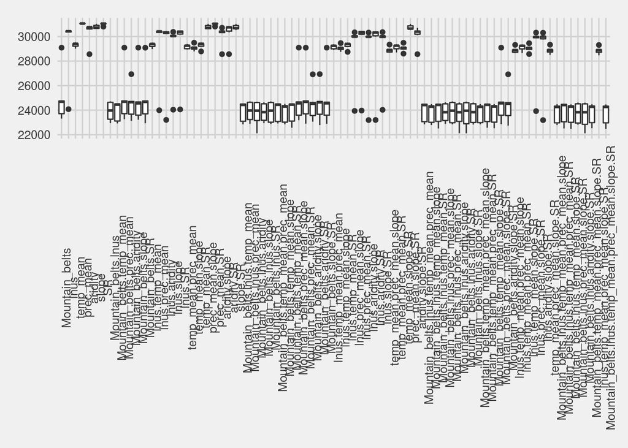

```r
## Representation of AIC variations
TAB_plot = COMPAR_melt[which(COMPAR_melt$variable == "AIC"),]
ggplot(TAB_plot, aes(x = VAR, y = value)) +
  geom_boxplot() +
  theme_fivethirtyeight() +
  theme(axis.text.x = element_text(angle = 90))
```

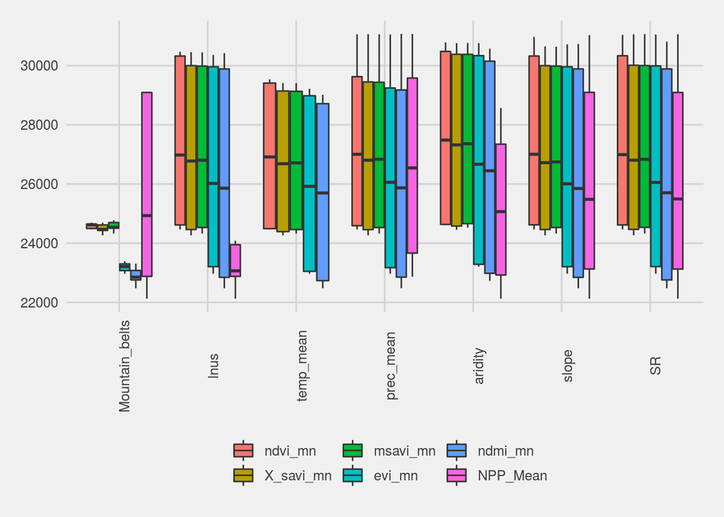

```r
## Representation of AIC variations for each prod variable and different number of explicative variables
# ggplot(TAB_plot, aes(x = PROD, y = value, group = VAR, color = GROUP3)) + #interaction(GROUP1,GROUP2))) +
#   geom_line() +
#   facet_grid(~ NB_VAR, scales = "free_y") +
#   scale_color_discrete("") +
#   theme_fivethirtyeight() +
#   theme(axis.text.x = element_text(angle = 90))

## Representation of AIC values whenever each explicative variable is included inside a model
TAB_plot2 = foreach(ve = vari_all, .combine = "rbind") %do%
{
  return(data.frame(VAR = ve
                    , variable = "AIC"
                    , value = TAB_plot$value[grep(ve, TAB_plot$VAR)]
                    , PROD = TAB_plot$PROD[grep(ve, TAB_plot$VAR)]))
}
ggplot(TAB_plot2, aes(x = VAR, y = value, fill = PROD)) +
  geom_boxplot() +
  scale_fill_discrete("") +
  theme_fivethirtyeight() +
  theme(axis.text.x = element_text(angle = 90))
```

# DEFINING M0 MODEL : some combinations but including temp_mean for NPP_Mean…

```r
## STEP 1: Computing initial plant biomass model (M0) with environment only
COMPAR = foreach(vari = vari_prod, .combine = "rbind") %do%
{
  # M0 = as.formula(paste0(vari, " ~ Mountain_belts + lnus + slope + temp_mean + prec_mean"))
  M0_glm = as.formula(paste0(vari, " ~ Mountain_belts + lnus + slope + temp_mean + prec_mean"))
  M0_gam = as.formula(paste0(vari, " ~ Mountain_belts + lnus + s(slope,4) + s(temp_mean,4) + s(prec_mean,4)"))
  M0_lmer_1 = as.formula(paste0(vari, " ~ Mountain_belts + lnus + slope + temp_mean + prec_mean + (1 | Mountain_belts) + (1 | lnus)"))
  M0_lmer_2 = as.formula(paste0(vari, " ~ Mountain_belts + lnus + slope + temp_mean + prec_mean + (1 | Mountain_belts) + (temp_mean | lnus)"))
  M0_lmer_3 = as.formula(paste0(vari, " ~ Mountain_belts + lnus + slope + temp_mean + prec_mean + (1 | Mountain_belts) + (temp_mean + prec_mean | lnus)"))
  M0_lmer_4 = as.formula(paste0(vari, " ~ Mountain_belts + lnus + slope + temp_mean + prec_mean + (temp_mean | Mountain_belts) + (temp_mean | lnus)"))
  M0_lmer_5 = as.formula(paste0(vari, " ~ Mountain_belts + lnus + slope + temp_mean + prec_mean + (temp_mean | Mountain_belts) + (temp_mean + prec_mean | lnus)"))

  mods = c("glm", "gam", paste0("lmer_", 1:5))
  for (mod in mods)
  {
    type_mod = strsplit(mod, "_")[[1]][1]
    supp_arg = ifelse(type_mod == "lmer"
                      , paste0(", control = lmerControl(optimizer = 'optimx', calc.derivs = FALSE,"
                               , "optCtrl = list(method = 'nlminb', starttests = FALSE, kkt = FALSE))")
                      , "")
    eval(parse(text = paste0("M0_", mod, " = ", type_mod, "(M0_", mod, ", data = env_data", supp_arg, ")")))
  }

  eval(parse(text = paste0("res = data.frame(VARI = vari"
                           , paste0(", AIC_", mods, " = AIC(M0_", mods, "), R2_"
                                    , mods, " = r.squaredGLMM(M0_", mods, ")[2]"
                                    , collapse = "")
                           , ")" )))
  return(res)
}
```

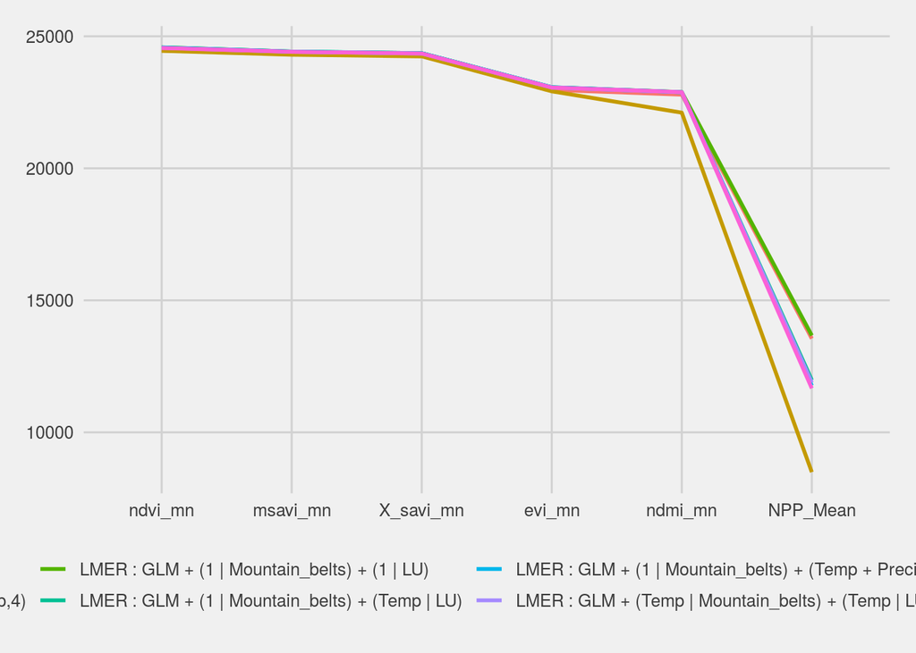

```r
## Rearrange data for graphical representation
COMPAR_melt = melt(COMPAR)
COMPAR_melt = COMPAR_melt[grep("AIC", COMPAR_melt$variable), ]
COMPAR_melt$VARI = factor(COMPAR_melt$VARI, c("ndvi_mn", "msavi_mn","X_savi_mn",
                                              "evi_mn", "ndmi_mn", "NPP_Mean"))
ggplot(COMPAR_melt, aes(x = VARI, y = value, group = variable, color = variable)) +
  geom_line(lwd = 1) +
  labs(x = "", y = "R squared") +
  scale_color_discrete("", labels = c("AIC_glm" = "GLM : MountainBelts + LU + Slope + Temp + Precip"
                                      , "AIC_gam" = "GAM : MountainBelts + LU + s(Slope,4) + s(Temp,4) + s(Precip,4)"
                                      , "AIC_lmer_1" = "LMER : GLM + (1 | Mountain_belts) + (1 | LU)"
                                      , "AIC_lmer_2" = "LMER : GLM + (1 | Mountain_belts) + (Temp | LU)"
                                      , "AIC_lmer_3" = "LMER : GLM + (1 | Mountain_belts) + (Temp + Precip | LU)"
                                      , "AIC_lmer_4" = "LMER : GLM + (Temp | Mountain_belts) + (Temp | LU)"
                                      , "AIC_lmer_5" = "LMER : GLM + (Temp | Mountain_belts) + (Temp + Precip | LU)")) +
  theme_fivethirtyeight()
```

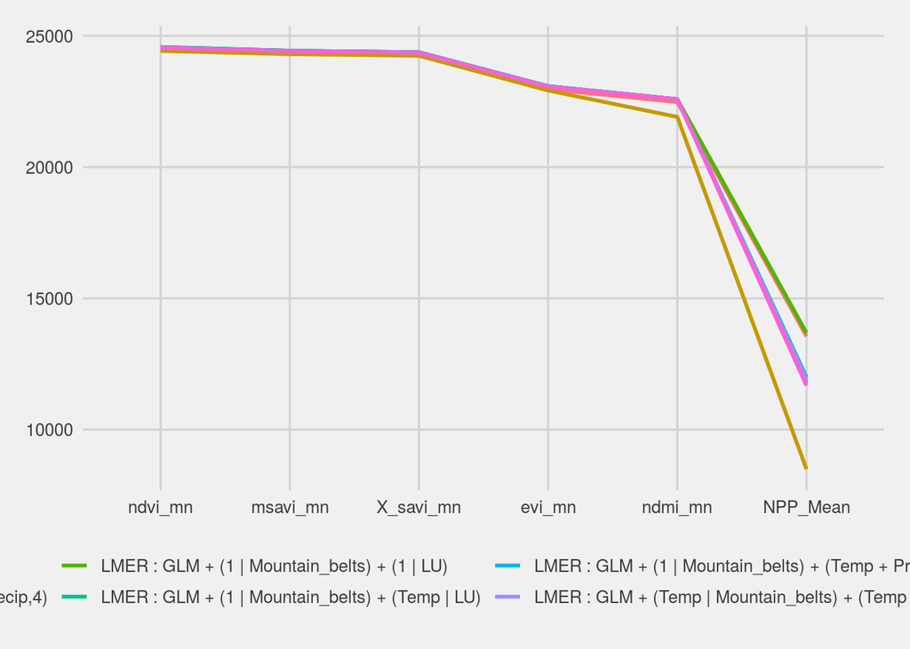

```r
# STEP 1: Computing initial plant biomass model (M0) with environment + SR
COMPAR = foreach(vari = vari_prod, .combine = "rbind") %do%
{
  # M0 = as.formula(paste0(vari, " ~ Mountain_belts + lnus + slope + temp_mean + prec_mean"))
  M0_glm = as.formula(paste0(vari, " ~ SR + Mountain_belts + lnus + slope + temp_mean + prec_mean"))
  M0_gam = as.formula(paste0(vari, " ~ SR + Mountain_belts + lnus + s(slope,4) + s(temp_mean,4) + s(prec_mean,4)"))
  M0_lmer_1 = as.formula(paste0(vari, " ~ SR + Mountain_belts + lnus + slope + temp_mean + prec_mean + (1 | Mountain_belts) + (1 | lnus)"))
  M0_lmer_2 = as.formula(paste0(vari, " ~ SR + Mountain_belts + lnus + slope + temp_mean + prec_mean + (1 | Mountain_belts) + (temp_mean | lnus)"))
  M0_lmer_3 = as.formula(paste0(vari, " ~ SR + Mountain_belts + lnus + slope + temp_mean + prec_mean + (1 | Mountain_belts) + (temp_mean + prec_mean | lnus)"))
  M0_lmer_4 = as.formula(paste0(vari, " ~ SR + Mountain_belts + lnus + slope + temp_mean + prec_mean + (temp_mean | Mountain_belts) + (temp_mean | lnus)"))
  M0_lmer_5 = as.formula(paste0(vari, " ~ SR + Mountain_belts + lnus + slope + temp_mean + prec_mean + (temp_mean | Mountain_belts) + (temp_mean + prec_mean | lnus)"))

  mods = c("glm", "gam", paste0("lmer_", 1:5))
  for (mod in mods)
  {
    type_mod = strsplit(mod, "_")[[1]][1]
    supp_arg = ifelse(type_mod == "lmer"
                      , paste0(", control = lmerControl(optimizer = 'optimx', calc.derivs = FALSE,"
                               , "optCtrl = list(method = 'nlminb', starttests = FALSE, kkt = FALSE))")
                      , "")
    eval(parse(text = paste0("M0_", mod, " = ", type_mod, "(M0_", mod, ", data = env_data", supp_arg, ")")))
  }

  eval(parse(text = paste0("res = data.frame(VARI = vari"
                           , paste0(", AIC_", mods, " = AIC(M0_", mods, "), R2_"
                                    , mods, " = r.squaredGLMM(M0_", mods, ")[2]"
                                    , collapse = "")
                           , ")" )))
  return(res)
}

## Rearrange data for graphical representation
COMPAR_melt = melt(COMPAR)
COMPAR_melt = COMPAR_melt[grep("AIC", COMPAR_melt$variable), ]
COMPAR_melt$VARI = factor(COMPAR_melt$VARI, c("ndvi_mn", "msavi_mn","X_savi_mn",
                                              "evi_mn", "ndmi_mn", "NPP_Mean"))
ggplot(COMPAR_melt, aes(x = VARI, y = value, group = variable, color = variable)) +
  geom_line(lwd = 1) +
  labs(x = "", y = "R squared") +
  scale_color_discrete("", labels = c("AIC_glm" = "GLM : SR + MountainBelts + LU + Slope + Temp + Precip"
                                      , "AIC_gam" = "GAM : SR + MountainBelts + LU + s(Slope,4) + s(Temp,4) + s(Precip,4)"
                                      , "AIC_lmer_1" = "LMER : GLM + (1 | Mountain_belts) + (1 | LU)"
                                      , "AIC_lmer_2" = "LMER : GLM + (1 | Mountain_belts) + (Temp | LU)"
                                      , "AIC_lmer_3" = "LMER : GLM + (1 | Mountain_belts) + (Temp + Precip | LU)"
                                      , "AIC_lmer_4" = "LMER : GLM + (Temp | Mountain_belts) + (Temp | LU)"
                                      , "AIC_lmer_5" = "LMER : GLM + (Temp | Mountain_belts) + (Temp + Precip | LU)")) +
  theme_fivethirtyeight()
```

# DEFINING M0 MODEL : some specific combinations for evi_mn and NPP_Mean

```r
## For EVI
mod_forms = c("glm(evi_mn ~ SR + Mountain_belts + lnus, data = env_data)"
              , "glm(evi_mn ~ SR + Mountain_belts + lnus + slope + temp_mean + prec_mean, data = env_data)"
              , "gam(evi_mn ~ SR + Mountain_belts + lnus + s(slope,4) + s(temp_mean,4) + s(prec_mean,4), data = env_data)"
              , paste0("lmer(evi_mn ~ SR + Mountain_belts + lnus + slope + temp_mean + prec_mean +"
                       , "(1 | Mountain_belts) + (1 | lnus)"
                       , ", data = env_data"
                       , ", control = lmerControl(optimizer = 'optimx', calc.derivs = FALSE"
                       , ", optCtrl = list(method = 'nlminb', starttests = FALSE, kkt = FALSE)))"))

for (i in 1:length(mod_forms)) { eval(parse(text = paste0("M0_", i, " = ", mod_forms[i]))) }

## Checking for robustness of M0 : AIC
for (i in 1:length(mod_forms)) { eval(parse(text = paste0("print(AIC(M0_", i, "))"))) }
```

```
## [1] 23303.7
## [1] 22967.44
## [1] 22916.94
## [1] 23076.62
```

```r
## Marginal and conditional R squared(variance explained by both fixed and random factors)
for (i in 1:length(mod_forms)) { eval(parse(text = paste0("print(r.squaredGLMM(M0_", i, "))"))) }
```

```
##       R2m       R2c
## 0.5095481 0.5095481
##       R2m       R2c
## 0.5245615 0.5245615
##       R2m       R2c
## 0.5224101 0.5224101
##       R2m       R2c
## 0.3215761 0.7085382
```

```r
## For NPP
mod_forms = c("glm(NPP_Mean ~ SR + Mountain_belts + lnus, data = env_data)"
              , "glm(NPP_Mean ~ SR + Mountain_belts + lnus + slope + aridity, data = env_data)"
              , "gam(NPP_Mean ~ SR + Mountain_belts + lnus + s(slope,4) + s(aridity,4), data = env_data)"
              , paste0("lmer(NPP_Mean ~ SR + Mountain_belts + lnus + slope + aridity +"
                       , "(1 | Mountain_belts) + (1 | lnus)"
                       , ", data = env_data"
                       , ", control = lmerControl(optimizer = 'optimx', calc.derivs = FALSE"
                       , ", optCtrl = list(method = 'nlminb', starttests = FALSE, kkt = FALSE)))"))

for (i in 1:length(mod_forms)) { eval(parse(text = paste0("M0_", i, " = ", mod_forms[i]))) }

## Checking for robustness of M0 : AIC
for (i in 1:length(mod_forms)) { eval(parse(text = paste0("print(AIC(M0_", i, "))"))) }
```

```
## [1] 22927.11
## [1] 22123.46
## [1] 21732.79
## [1] 22226.82
```

```r
## Marginal and conditional R squared(variance explained by both fixed and random factors)
for (i in 1:length(mod_forms)) { eval(parse(text = paste0("print(r.squaredGLMM(M0_", i, "))"))) }
```

```
##       R2m       R2c
## 0.5261169 0.5261169
##       R2m       R2c
## 0.5597439 0.5597439
##       R2m       R2c
## 0.5584601 0.5584601
##       R2m       R2c
## 0.3146623 0.7525082
```

# RUN ROUTINE (M0, add species, functional space)

## STEP 1: Computing initial plant biomass model (M0)

```r
mod_form = "gam(evi_mn ~ SR + Mountain_belts + lnus + s(slope,4) + s(temp_mean,4) + s(prec_mean,4), data = env_data)"
mod_form = "gam(NPP_Mean ~ SR + Mountain_belts + lnus + s(slope,4) + s(aridity,4), data = env_data)"

eval(parse(text = paste0("M0 = ", mod_form)))

## Checking for robustness of M0
AIC(M0)
```

```
## [1] 21732.79
```

```r
r.squaredGLMM(M0)[2] ## conditional (variance explained by both fixed and random factors)
```

```
##       R2c
## 0.5584601
```

```r
## Storing AIC of M0 that will be the threshold to define which species improve the prediction of plant biomass
AIC_M0 <- AIC(M0)
```

## STEP 2: TESTING THE EFFECT OF EACH plant SPECIES INDIVIDUALLY

For each candidate species, an alternative model (M1) is obtained by adding the presence/absence of this plant species to M0 AIC of M1 and the effect (positive or negative) of the candidate species are saved.

```r
## Results for all species will be stored in the Test_candidates matrix
Test_candidates <- matrix(NA,length(candidates_species),3)
colnames(Test_candidates) <- c("occurrence","AIC_M1","coeff_sp")
rownames(Test_candidates) <- candidates_species

cat(" \n ==> CANDIDATE ")
```

```
##
##  ==> CANDIDATE
```

```r
for (k in 1:length(candidates_species)) {
  cat(" ", k)

  # Defining presence/absence of the species k
  candidate <- as.factor(presence_candidates[,k])
  Test_candidates[k,"occurrence"] <- length(which(candidate==1))

  data_with_candidate <- as.data.frame(cbind(env_data,candidate))

  ## Adding presence/absence of species k to M0 to obtain M1
  mod_form_M1 = sub("env_data", "data_with_candidate", mod_form)
  mod_form_M1 = sub("SR", "candidate + SR", mod_form_M1)
  eval(parse(text = paste0("M1 = ", mod_form_M1)))

  Test_candidates[k,"AIC_M1"] <- AIC(M1)
  if (length(grep("lmer", mod_form)) > 0)
  {
    Test_candidates[k,"coeff_sp"] <- unique(unlist(coef(M1)$lnus[grep("candidate", names(coef(M1)$lnus))]))
  } else
  {
    Test_candidates[k,"coeff_sp"] <- unique(coef(M1)[grep("candidate", names(coef(M1)))])
  }
} # end of k
```

```
##   1  2  3  4  5  6  7  8  9  10  11  12  13  14  15  16  17  18  19  20  21  22  23  24  25  26  27  28  29  30  31  32  33  34  35  36  37  38  39  40  41  42  43  44  45  46  47  48  49  50  51  52  53  54  55  56  57  58  59  60  61  62  63  64  65  66  67  68  69  70  71  72  73  74  75  76  …
```

```r
Test_candidates <- as.data.frame(Test_candidates)
# save(Test_candidates, file = "Test_candidates_glm.RData")
```

## STEP 3: Determining species that improve the prediction of plant biomass as ΔAIC (AIC_M0 - AIC_M1) > 4 with a positive effect

```r
Delta_AIC <- AIC_M0 - Test_candidates$AIC_M1
better_AIC <- ifelse(Delta_AIC >= 4, 1, 0)
positive_coef <- ifelse(Test_candidates$coeff_sp > 0, 1, 0)

key_species <- which(better_AIC == 1 & positive_coef == 1)

## Extracting matrix that combines "key species" and their performances in the model
Summary_key_species <- cbind(Test_candidates,Delta_AIC)[key_species,]
## plant species that are significantly and positively related to plant biomass
nrow(Summary_key_species)
```

```
## [1] 72
```

## STEP 4: visualizing these species into the functional space

```r
func_tab = na.exclude(Functional_traits[, c("SLA","PL_VEG_H","SEEDM")])
dim(func_tab)
```

```
## [1] 1210    3
```

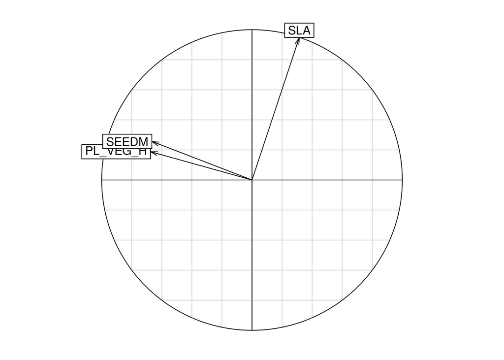

```r
acp = dudi.hillsmith(func_tab, scannf = F, nf = 4)
s.corcircle(acp$c1)
```

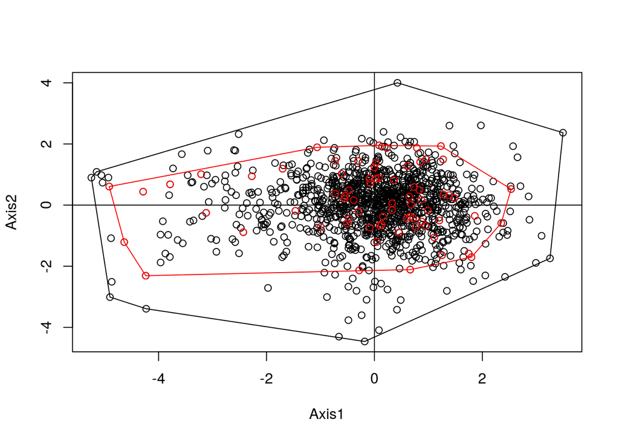

```r
## Representing 2 axis with all species in black and key species in red
ii = c(1,2)
xy_0 = acp$li[, ii]
xy_1 = acp$li[which(rownames(acp$li) %in% rownames(Summary_key_species)), ii]
chu_0 = chull(xy_0)
chu_1 = chull(xy_1)
plot(xy_0)
abline(h = 0, v = 0)
lines(xy_0[c(chu_0,chu_0[1]),])
points(xy_1, col = "red")
lines(xy_1[c(chu_1,chu_1[1]),], col = "red")
```